# Serology data QC, seroprevalence, and power analysis

Parvovirus B19 IgG serosurvey, Belgium (n = 3,080)

Niti B. Jadeja, Ph.D.

October 12, 2026

# 1 Purpose

This project works through the analyses a laboratory data analyst runs on serology data, using a real, public serosurvey:

1. **Data QC**: completeness, range checks, and agreement between the quantitative antibody result and the qualitative positive/negative call.
2. **Assay cutoff check**: an independent, data-driven cutoff from a two-component mixture model, compared with the reported calls.
3. **Seroprevalence**: estimates by age group with 95% confidence intervals, and a logistic regression of seropositivity on age and sex.
4. **Study design and power**: sample size for precise seroprevalence estimates, power for comparing two groups, and simulation-based power for a planned age-adjusted serosurvey.

**Data.** Parvovirus B19 IgG antibody concentrations (IU/mL) and serostatus for 3,080 residual sera from a Belgian national serum bank, line-listed in the open-source R package *serosv* (MIT license). Original study: Mossong J, Hens N, et al. *Parvovirus B19 infection in five European countries: seroepidemiology, force of infection and maternal risk of infection.* Epidemiology and Infection 136(8):1059–68 (2008). doi:10.1017/S0950268807009661.

```r
d <- read.csv("data/parvob19_be_serology.csv")
d$gender <- factor(d$gender, levels = c("f", "m"), labels = c("Female", "Male"))
str(d)
```

```
## 'data.frame':    3080 obs. of  5 variables:
##  $ age         : int  0 0 0 0 0 1 1 1 1 1 ...
##  $ seropositive: int  1 0 0 0 0 0 1 1 1 1 ...
##  $ year        : int  2001 2001 2001 2001 2001 2001 2001 2001 2001 2001 ...
##  $ gender      : Factor w/ 2 levels "Female","Male": 2 2 2 2 2 2 2 2 2 2 ...
##  $ parvouml    : num  177.76 4.81 3.61 2.48 1.45 ...
```

# 2 Data quality control

## 2.1 Completeness and ranges

```r
qc <- data.frame(
  variable = names(d),
  missing_n = sapply(d, function(x) sum(is.na(x))),
  missing_pct = round(100 * sapply(d, function(x) mean(is.na(x))), 1)
)
knitr::kable(qc, row.names = FALSE, caption = "Missing values by variable")
```

Missing values by variable

| variable | missing_n | missing_pct |
| --- | --- | --- |
| age | 0 | 0.0 |
| seropositive | 0 | 0.0 |
| year | 0 | 0.0 |
| gender | 0 | 0.0 |
| parvouml | 226 | 7.3 |

```r
range_checks <- c(
  age_out_of_range   = sum(d$age < 0 | d$age > 100, na.rm = TRUE),
  conc_nonpositive   = sum(d$parvouml <= 0, na.rm = TRUE),
  status_not_0_or_1  = sum(!d$seropositive %in% c(0, 1)),
  duplicated_rows    = sum(duplicated(d))
)
knitr::kable(data.frame(check = names(range_checks), n_records = range_checks),
             row.names = FALSE, caption = "Range and consistency checks")
```

Range and consistency checks

| check | n_records |
| --- | --- |
| age_out_of_range | 0 |
| conc_nonpositive | 0 |
| status_not_0_or_1 | 0 |
| duplicated_rows | 185 |

226 records (7.3%) have a serostatus but no quantitative result. They stay in the prevalence analyses but are excluded from the cutoff analysis.

## 2.2 Agreement between concentration and serostatus

Antibody concentrations are strongly right-skewed, so they are analyzed on the log10 scale. If the qualitative calls follow a single cutoff, the two groups should not overlap.

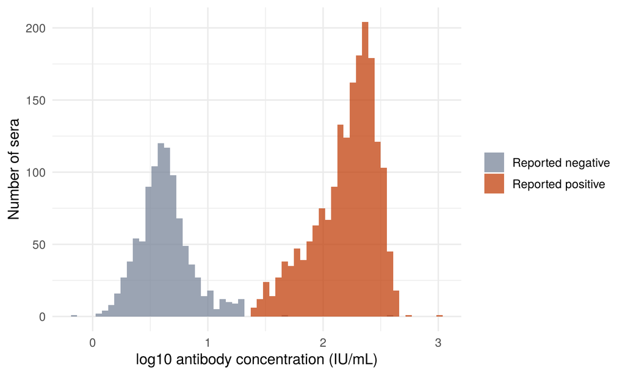

Antibody concentration by reported serostatus

```r
q <- subset(d, !is.na(parvouml))
q$status <- factor(q$seropositive, labels = c("Reported negative", "Reported positive"))
ggplot(q, aes(log10(parvouml), fill = status)) +
  geom_histogram(bins = 60, alpha = 0.75, position = "identity") +
  scale_fill_manual(values = c("#7A869A", "#C2410C")) +
  labs(x = "log10 antibody concentration (IU/mL)", y = "Number of sera", fill = NULL)
```

```r
min_pos <- min(q$parvouml[q$seropositive == 1])
max_neg_below <- max(q$parvouml[q$seropositive == 0 & q$parvouml < min_pos])
# discordant: reported negative above the lowest positive, or reported positive below the highest negative
overlap <- subset(q, (seropositive == 0 & parvouml >= min_pos) |
                     (seropositive == 1 & parvouml <= max_neg_below))
c(lowest_positive = min_pos, highest_regular_negative = max_neg_below,
  discordant_records = nrow(overlap))
```

```
##          lowest_positive highest_regular_negative       discordant_records
##                   24.051                   19.881                    2.000
```

Almost all negatives fall below 19.9 IU/mL and all positives lie at or above 24.1 IU/mL. The empty gap between them is consistent with an equivocal zone in the assay. 2 reported negatives sit above the lowest positive. They are candidates for source verification: a transcription error, a retest, or an equivocal result recorded as negative.

```r
flags <- overlap[order(-overlap$parvouml), c("age", "gender", "parvouml", "seropositive")]
knitr::kable(head(flags, 10), row.names = FALSE,
             caption = "Records whose serostatus disagrees with their concentration")
```

Records whose serostatus disagrees with their concentration

| age | gender | parvouml | seropositive |
| --- | --- | --- | --- |
| 14 | Female | 360.424 | 0 |
| 32 | Female | 48.583 | 0 |

# 3 Assay cutoff check with a mixture model

A two-component Gaussian mixture on log10 concentration estimates the seronegative and seropositive populations without using the reported calls. The cutoff is where a serum is equally likely to belong to either component.

```r
x <- log10(q$parvouml)
fit <- normalmixEM(x, k = 2, mu = c(0.5, 2.2), sigma = c(0.3, 0.3), verb = FALSE)
```

```
## number of iterations= 12
```

```r
neg <- which.min(fit$mu); pos <- which.max(fit$mu)
post_pos <- function(v) {
  a <- fit$lambda[pos] * dnorm(v, fit$mu[pos], fit$sigma[pos])
  b <- fit$lambda[neg] * dnorm(v, fit$mu[neg], fit$sigma[neg])
  a / (a + b)
}
cut_log <- uniroot(function(v) post_pos(v) - 0.5, c(fit$mu[neg], fit$mu[pos]))$root
cutoff <- 10^cut_log
mix_tab <- data.frame(
  component = c("Seronegative", "Seropositive"),
  proportion = round(fit$lambda[c(neg, pos)], 3),
  geometric_mean_IU_mL = round(10^fit$mu[c(neg, pos)], 1),
  sd_log10 = round(fit$sigma[c(neg, pos)], 3)
)
knitr::kable(mix_tab, caption = "Two-component mixture model fit")
```

Two-component mixture model fit

| component | proportion | geometric_mean_IU_mL | sd_log10 |
| --- | --- | --- | --- |
| Seronegative | 0.345 | 4.2 | 0.219 |
| Seropositive | 0.655 | 156.4 | 0.272 |

The mixture-model cutoff is **20.2 IU/mL**.

```r
q$mix_call <- as.integer(q$parvouml >= cutoff)
tab <- table(Reported = q$seropositive, Mixture = q$mix_call)
po <- sum(diag(tab)) / sum(tab)
pe <- sum(rowSums(tab) * colSums(tab)) / sum(tab)^2
kappa <- (po - pe) / (1 - pe)
tab
```

```
##         Mixture
## Reported    0    1
##        0  991    2
##        1    0 1861
```

```r
c(percent_agreement = round(100 * po, 2), cohens_kappa = round(kappa, 3))
```

```
## percent_agreement      cohens_kappa
##            99.930             0.998
```

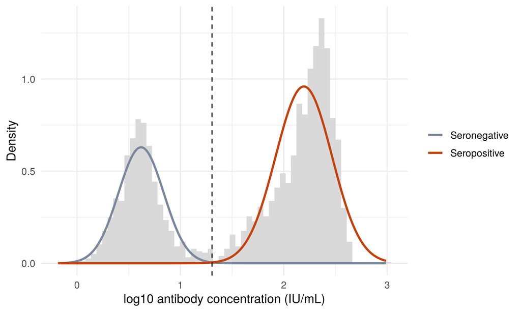

Mixture components and the derived cutoff

```r
grid <- seq(min(x), max(x), length.out = 400)
dens <- data.frame(
  x = rep(grid, 2),
  y = c(fit$lambda[neg] * dnorm(grid, fit$mu[neg], fit$sigma[neg]),
        fit$lambda[pos] * dnorm(grid, fit$mu[pos], fit$sigma[pos])),
  component = rep(c("Seronegative", "Seropositive"), each = length(grid))
)
ggplot() +
  geom_histogram(aes(x, after_stat(density)), data = data.frame(x = x),
                 bins = 60, fill = "grey85") +
  geom_line(aes(x, y, colour = component), data = dens, linewidth = 1) +
  geom_vline(xintercept = cut_log, linetype = 2) +
  scale_colour_manual(values = c("#7A869A", "#C2410C")) +
  labs(x = "log10 antibody concentration (IU/mL)", y = "Density", colour = NULL)
```

**Interpretation.** Agreement between the data-driven cutoff and the reported calls is high (kappa = 0.998). The only disagreements are the records flagged in Section 2, which supports reviewing those records rather than changing the cutoff.

# 4 Seroprevalence

## 4.1 By age group, with Wilson 95% confidence intervals

```r
wilson <- function(x, n, z = 1.96) {
  p <- x / n
  centre <- (p + z^2 / (2 * n)) / (1 + z^2 / n)
  half <- z * sqrt(p * (1 - p) / n + z^2 / (4 * n^2)) / (1 + z^2 / n)
  c(lower = centre - half, upper = centre + half)
}
d$age_group <- cut(d$age, c(-1, 5, 10, 15, 20, 30, 40, 60, 90),
                   labels = c("0-5", "6-10", "11-15", "16-20", "21-30", "31-40", "41-60", "61+"))
prev <- do.call(rbind, lapply(split(d, d$age_group), function(g) {
  ci <- wilson(sum(g$seropositive), nrow(g))
  data.frame(n = nrow(g), positive = sum(g$seropositive),
             prevalence = mean(g$seropositive), lower = ci[1], upper = ci[2])
}))
prev$age_group <- factor(rownames(prev), levels = levels(d$age_group))
knitr::kable(transform(prev[, c("age_group", "n", "positive")],
                       prevalence = sprintf("%.1f%% (%.1f-%.1f)", 100 * prev$prevalence,
                                            100 * prev$lower, 100 * prev$upper)),
             row.names = FALSE, caption = "Seroprevalence (95% CI) by age group")
```

Seroprevalence (95% CI) by age group

| age_group | n | positive | prevalence |
| --- | --- | --- | --- |
| 0-5 | 350 | 64 | 18.3% (14.6-22.7) |
| 6-10 | 391 | 217 | 55.5% (50.5-60.3) |
| 11-15 | 411 | 272 | 66.2% (61.5-70.6) |
| 16-20 | 550 | 425 | 77.3% (73.6-80.6) |
| 21-30 | 398 | 286 | 71.9% (67.2-76.1) |
| 31-40 | 384 | 288 | 75.0% (70.4-79.1) |
| 41-60 | 416 | 331 | 79.6% (75.4-83.2) |
| 61+ | 180 | 152 | 84.4% (78.4-89.0) |

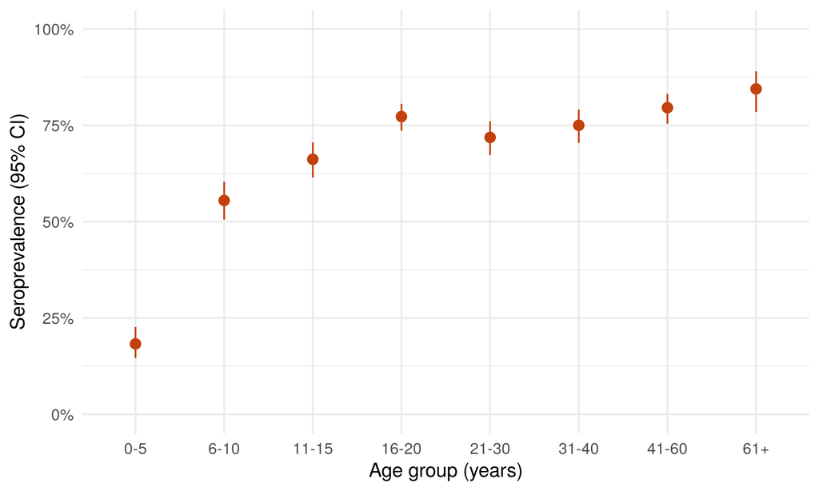

Seroprevalence by age group

```r
ggplot(prev, aes(age_group, prevalence)) +
  geom_pointrange(aes(ymin = lower, ymax = upper), colour = "#C2410C") +
  scale_y_continuous(labels = scales::percent, limits = c(0, 1)) +
  labs(x = "Age group (years)", y = "Seroprevalence (95% CI)")
```

## 4.2 Logistic regression: age and sex

Seroprevalence rises steeply through childhood and then plateaus, so age enters the model as a natural cubic spline (4 degrees of freedom) rather than a straight line.

```r
m <- glm(seropositive ~ ns(age, df = 4) + gender, family = binomial, data = d)
or_sex <- exp(cbind(OR = coef(m), confint.default(m)))["genderMale", ]
round(or_sex, 2)
```

```
##     OR  2.5 % 97.5 %
##   0.86   0.73   1.02
```

```r
anova(m, test = "LRT")
```

```
## Analysis of Deviance Table
##
## Model: binomial, link: logit
##
## Response: seropositive
##
## Terms added sequentially (first to last)
##
##
##                 Df Deviance Resid. Df Resid. Dev Pr(>Chi)
## NULL                             3079     3945.9
## ns(age, df = 4)  4   501.12      3075     3444.7  < 2e-16 ***
## gender           1     3.12      3074     3441.6  0.07756 .
## ---
## Signif. codes:  0 '***' 0.001 '**' 0.01 '*' 0.05 '.' 0.1 ' ' 1
```

The adjusted odds ratio for male vs female sex is 0.86 (95% CI 0.73-1.02).

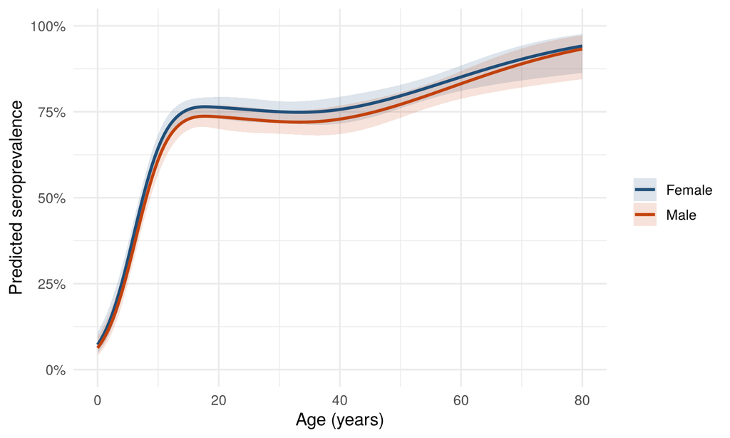

Model-based seroprevalence by age and sex

```r
nd <- expand.grid(age = seq(0, 80, by = 0.5), gender = levels(d$gender))
pr <- predict(m, nd, type = "link", se.fit = TRUE)
nd$fit <- plogis(pr$fit); nd$lo <- plogis(pr$fit - 1.96 * pr$se.fit)
nd$hi <- plogis(pr$fit + 1.96 * pr$se.fit)
ggplot(nd, aes(age, fit, colour = gender, fill = gender)) +
  geom_ribbon(aes(ymin = lo, ymax = hi), alpha = 0.15, colour = NA) +
  geom_line(linewidth = 1) +
  scale_y_continuous(labels = scales::percent, limits = c(0, 1)) +
  scale_colour_manual(values = c("#1F4E79", "#C2410C")) +
  scale_fill_manual(values = c("#1F4E79", "#C2410C")) +
  labs(x = "Age (years)", y = "Predicted seroprevalence", colour = NULL, fill = NULL)
```

# 5 Study design and power

This section answers the planning questions an investigator would bring before a new serosurvey. Each calculation uses this survey as the pilot.

## 5.1 Sample size for a precise prevalence estimate

The number of sera needed so that the 95% confidence interval has half-width *E*, inflated by a design effect for clustered sampling:

$$n = \text{DEFF} \times
\frac{z^2\,p(1-p)}{E^2}$$

```r
n_precision <- function(p, E, deff = 1, z = 1.96) ceiling(deff * z^2 * p * (1 - p) / E^2)
ps <- c(child_0_5 = prev["0-5", "prevalence"], child_6_10 = prev["6-10", "prevalence"],
        adult_21_30 = prev["21-30", "prevalence"])
grid <- expand.grid(group = names(ps), E = c(0.03, 0.05, 0.10), deff = c(1, 1.5))
grid$p <- round(ps[grid$group], 3)
grid$n_required <- mapply(n_precision, grid$p, grid$E, grid$deff)
knitr::kable(grid, caption = "Sera required per group for a given precision (E = CI half-width)")
```

Sera required per group for a given precision (E = CI half-width)

| group | E | deff | p | n_required |
| --- | --- | --- | --- | --- |
| child_0_5 | 0.03 | 1.0 | 0.183 | 639 |
| child_6_10 | 0.03 | 1.0 | 0.555 | 1055 |
| adult_21_30 | 0.03 | 1.0 | 0.719 | 863 |
| child_0_5 | 0.05 | 1.0 | 0.183 | 230 |
| child_6_10 | 0.05 | 1.0 | 0.555 | 380 |
| adult_21_30 | 0.05 | 1.0 | 0.719 | 311 |
| child_0_5 | 0.10 | 1.0 | 0.183 | 58 |
| child_6_10 | 0.10 | 1.0 | 0.555 | 95 |
| adult_21_30 | 0.10 | 1.0 | 0.719 | 78 |
| child_0_5 | 0.03 | 1.5 | 0.183 | 958 |
| child_6_10 | 0.03 | 1.5 | 0.555 | 1582 |
| adult_21_30 | 0.03 | 1.5 | 0.719 | 1294 |
| child_0_5 | 0.05 | 1.5 | 0.183 | 345 |
| child_6_10 | 0.05 | 1.5 | 0.555 | 570 |
| adult_21_30 | 0.05 | 1.5 | 0.719 | 466 |
| child_0_5 | 0.10 | 1.5 | 0.183 | 87 |
| child_6_10 | 0.10 | 1.5 | 0.555 | 143 |
| adult_21_30 | 0.10 | 1.5 | 0.719 | 117 |

## 5.2 Power to compare seroprevalence between two groups

Cohen’s *h* (arcsine-transformed difference in proportions) with `pwr::pwr.2p.test`. Example question: how many sera per group to detect a 10-percentage-point difference in seroprevalence in 6–10-year-olds between two regions?

```r
p1 <- prev["6-10", "prevalence"]
h <- ES.h(p1 + 0.10, p1)
n80 <- pwr.2p.test(h = h, power = 0.80, sig.level = 0.05)$n
n90 <- pwr.2p.test(h = h, power = 0.90, sig.level = 0.05)$n
c(baseline_prevalence = round(p1, 3), cohens_h = round(h, 3),
  n_per_group_80pct = ceiling(n80), n_per_group_90pct = ceiling(n90))
```

```
## baseline_prevalence            cohens_h   n_per_group_80pct   n_per_group_90pct
##               0.555               0.205             374.000             501.000
```

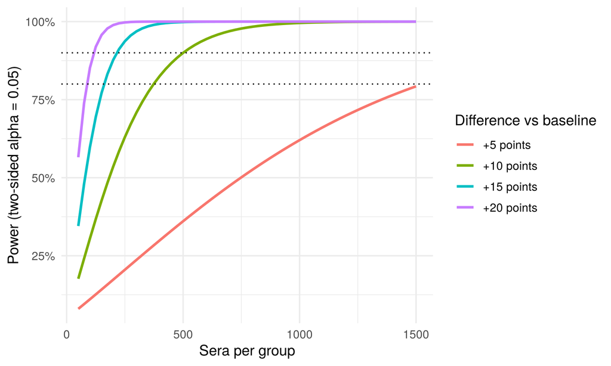

Power to detect a difference in seroprevalence, by sample size per group

```r
diffs <- c(0.05, 0.10, 0.15, 0.20)
ns <- seq(50, 1500, by = 25)
pc <- do.call(rbind, lapply(diffs, function(dd) data.frame(
  n = ns, difference = paste0("+", 100 * dd, " points"),
  power = pwr.2p.test(h = ES.h(p1 + dd, p1), n = ns, sig.level = 0.05)$power)))
pc$difference <- factor(pc$difference, levels = paste0("+", 100 * diffs, " points"))
ggplot(pc, aes(n, power, colour = difference)) +
  geom_line(linewidth = 1) +
  geom_hline(yintercept = c(0.8, 0.9), linetype = 3) +
  scale_y_continuous(labels = scales::percent) +
  labs(x = "Sera per group", y = "Power (two-sided alpha = 0.05)", colour = "Difference vs baseline")
```

## 5.3 How sensitive was this survey to a sex difference?

A non-significant result means little without knowing the study’s power. Using the observed group sizes, this is the smallest sex difference the survey could reliably detect.

```r
nf <- sum(d$gender == "Female"); nm <- sum(d$gender == "Male")
p_overall <- mean(d$seropositive)
h_min <- pwr.2p2n.test(n1 = nf, n2 = nm, power = 0.80, sig.level = 0.05)$h
# convert the detectable h back to a difference in proportions around the overall prevalence
p_detect <- sin(asin(sqrt(p_overall)) + h_min / 2)^2
c(n_female = nf, n_male = nm, detectable_h = round(h_min, 3),
  detectable_difference_pct_points = round(100 * (p_detect - p_overall), 1))
```

```
##                         n_female                           n_male
##                         1566.000                         1514.000
##                     detectable_h detectable_difference_pct_points
##                            0.101                            4.700
```

## 5.4 Simulation-based power for an age-adjusted design

Closed-form formulas assume a simple two-group comparison. A real serosurvey adjusts for age, so this simulation uses the fitted age curve from Section 4 as the true baseline, adds a region effect (odds ratio 1.5), and repeats the planned analysis many times at each sample size.

```r
sim_power <- function(n_total, or = 1.5, reps = 400) {
  base <- glm(seropositive ~ ns(age, df = 4), family = binomial, data = d)
  hits <- replicate(reps, {
    s <- d[sample(nrow(d), n_total, replace = TRUE), "age", drop = FALSE]
    s$region <- rbinom(n_total, 1, 0.5)
    lp <- predict(base, newdata = s, type = "link") + log(or) * s$region
    s$y <- rbinom(n_total, 1, plogis(lp))
    fit <- glm(y ~ ns(age, df = 4) + region, family = binomial, data = s)
    summary(fit)$coefficients["region", "Pr(>|z|)"] < 0.05
  })
  mean(hits)
}
sizes <- c(300, 500, 700, 900, 1200, 1500)
sp <- data.frame(n_total = sizes, power = sapply(sizes, sim_power))
sp$mc_se <- round(sqrt(sp$power * (1 - sp$power) / 400), 3)
knitr::kable(sp, caption = "Simulated power to detect OR = 1.5 for region, adjusted for age (400 simulations each)")
```

Simulated power to detect OR = 1.5 for region, adjusted for age (400 simulations each)

| n_total | power | mc_se |
| --- | --- | --- |
| 300 | 0.3700 | 0.024 |
| 500 | 0.4575 | 0.025 |
| 700 | 0.5950 | 0.025 |
| 900 | 0.7475 | 0.022 |
| 1200 | 0.8225 | 0.019 |
| 1500 | 0.9250 | 0.013 |

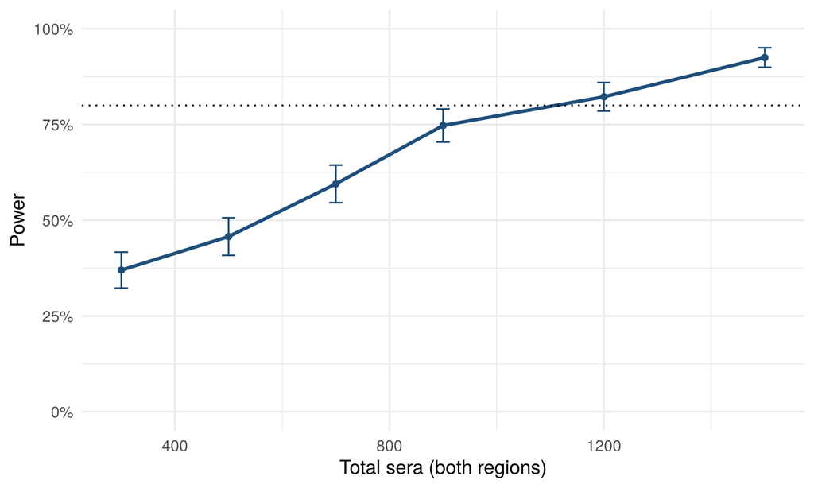

Simulated power for an age-adjusted region comparison

```r
ggplot(sp, aes(n_total, power)) +
  geom_line(colour = "#1F4E79", linewidth = 1) + geom_point(colour = "#1F4E79") +
  geom_errorbar(aes(ymin = power - 1.96 * mc_se, ymax = power + 1.96 * mc_se),
                width = 25, colour = "#1F4E79") +
  geom_hline(yintercept = 0.8, linetype = 3) +
  scale_y_continuous(labels = scales::percent, limits = c(0, 1)) +
  labs(x = "Total sera (both regions)", y = "Power")
```

# 6 Summary

- **QC:** 7.3% of records lack a quantitative result, and 2 records have a serostatus that disagrees with their concentration; these were flagged for source verification rather than silently corrected.
- **Cutoff:** an independent mixture-model cutoff (20.2 IU/mL) agrees closely with the reported calls (kappa 0.998).
- **Epidemiology:** seroprevalence rises from 18% at ages 0–5 to 84% over 60; sex has no clear effect after adjusting for age (OR 0.86).
- **Design:** detecting a 10-point difference in 6–10-year-olds needs about 374 sera per group for 80% power; an age-adjusted comparison at OR 1.5 reaches 80% power at about 1200 sera in total (Section 5.4).

**Limitations.** Residual sera are a convenience sample, so prevalence may not represent the general population; the simulation assumes the fitted age curve is correct and that region is independent of age.